# Comparing groups

Esko

10.01.2016

Now we look for ways to compare goups using plots and statistical tests.

First, let’s load the same data as in 1.3.1. I will also write the parametrization and aggregation again.

```r
satest <- read.table("satest_sample_data.txt", header=TRUE)
satest.bg <- read.table("satest_bgdata.txt", header=TRUE)


satest$correct <- ((satest$answer == 'notpresent') & (satest$target_type == 'nothing')) |
  ((satest$answer == 'present') & (satest$target_type != 'nothing'))

require(plyr)
corrects <- ddply(satest, .(age_grp, player_id), summarize,
      correct.mean = mean(correct))

corrects
```

```
##    age_grp player_id correct.mean
## 1        A    401_y1    0.7721519
## 2        A    402_y2    0.8169014
## 3        A    403_y1    0.8169014
## 4        A    404_y2    0.8115942
## 5        A    405_y1    0.8356164
## 6        A    406_y2    0.7323944
## 7        A    407_y1    0.7200000
## 8        A    408_y2    0.7600000
## 9        A    409_y1    0.7466667
## 10       A    410_y2    0.7391304
## 11       A    411_y1    0.7101449
## 12       A    412_y2    0.8260870
## 13       A    413_y1    0.8450704
## 14       A    414_y2    0.7792208
```

[output cut: 67 more lines]

## Boxplot

I typically prefer to plot the data graphically, especially when exploring what is going on.

Now we have a continous variable correct.mean and we would like to compare two groups. For this purpose, boxplot is very useful. In R, boxplots can plotted using function boxplot.

This function was two ways to use it. The way is selected based on the first parameter given. If the first parameter is a data frame, the function makes a boxplot out of all the variables. When given a single variable, the results is a boxplot over all the values.

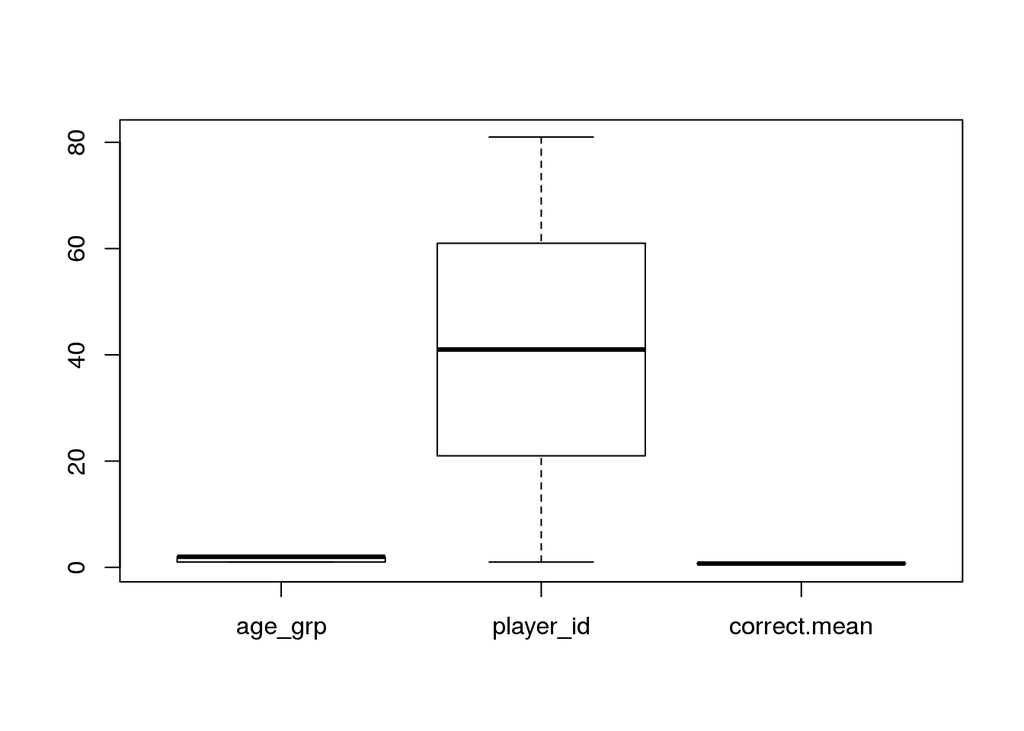

```r
boxplot(corrects) # not very informative here because the variables are not on the same scale
```

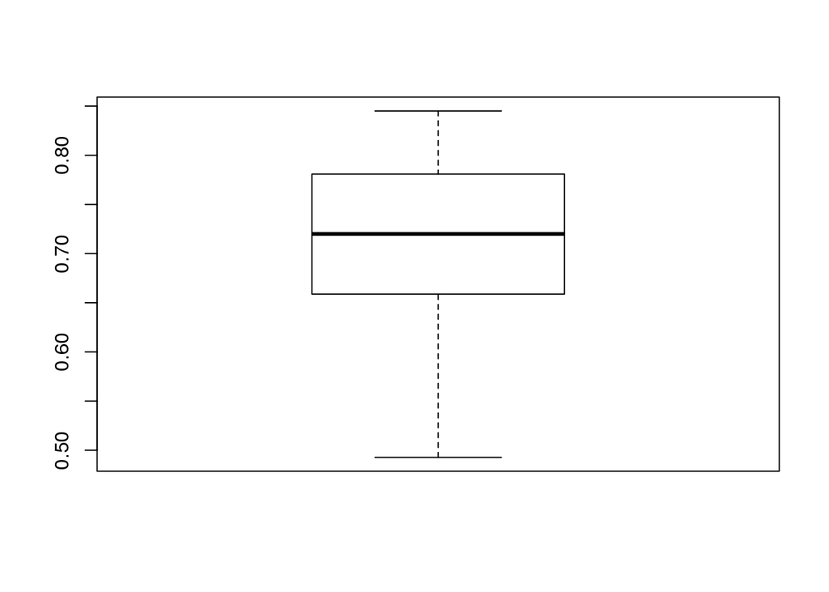

```r
boxplot(corrects$correct.mean) # ok
```

The most useful way to use boxplot here is to give a formula as the first parameter.

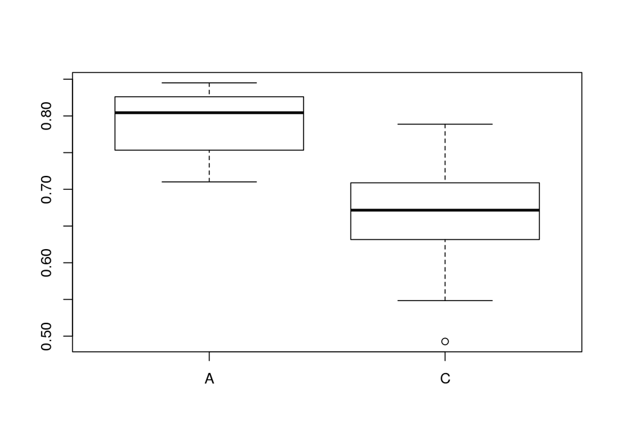

```r
boxplot(correct.mean ~ age_grp, corrects)
```

The formulas are given with tilde ~. The variable on the left of the tilde is the variable to be boxplotted, and the variable on the right is the grouping variable. This should be a factor when used with function boxplot.

## t-test

Using the same idea, it is easy to make between groups t-test.

```r
t.test(correct.mean ~ age_grp, corrects)
```

```
##
##  Welch Two Sample t-test
##
## data:  correct.mean by age_grp
## t = 10.171, df = 78.987, p-value = 5.162e-16
## alternative hypothesis: true difference in means is not equal to 0
## 95 percent confidence interval:
##  0.09748909 0.14493026
## sample estimates:
## mean in group A mean in group C
##       0.7896861       0.6684764
```

Typically, it would just fine to copy the information from the output to an article manuscript. However, sometimes it would be useful to have a programmatic access to the results of a test. In R, it is possible, even quite easy (at least compared to SPSS…) Look at the documentation of function t.test. Under heading Value, there are listed what components the return values contains. You can access these components with $.

```r
res <- t.test(correct.mean ~ age_grp, corrects)

res$estimate # estimated means
```

```
## mean in group A mean in group C
##       0.7896861       0.6684764
```

```r
res$estimate[1] # this is actually a vector, even thought it contains the name
```

```
## mean in group A
##       0.7896861
```

```r
res$estimate[2]
```

```
## mean in group C
##       0.6684764
```

```r
res$conf.int
```

```
## [1] 0.09748909 0.14493026
## attr(,"conf.level")
## [1] 0.95
```

```r
res$conf.int[1]
```

```
## [1] 0.09748909
```

```r
res$conf.int[2]
```

```
## [1] 0.1449303
```

Combining this with ddply, it is possible to create a table with means and 95 % confidence intervals for the group means.

```r
corrects.M_95CI <- ddply(corrects, .(age_grp), summarize,
      M = mean(correct.mean),
      CI.lower = t.test(correct.mean)$conf.int[1],
      CI.upper = t.test(correct.mean)$conf.int[2])

corrects.M_95CI
```

```
##   age_grp         M  CI.lower  CI.upper
## 1       A 0.7896861 0.7745818 0.8047903
## 2       C 0.6684764 0.6497038 0.6872490
```

# Merging two data files

Is there any difference between males and females? In order to make a similar comparision, we need to somehow merge the satest performance data and the background data. This happens with function merge.

```r
satest.merged <- merge(satest, satest.bg, by="player_id")
```

That was easy.

Now we can do the same as previous with this merged data.

```r
corrects <- ddply(satest.merged, .(age_grp, sex, player_id), summarize,
      correct.mean = mean(correct))

corrects
```

```
##    age_grp sex player_id correct.mean
## 1        A   f    401_y1    0.7721519
## 2        A   f    402_y2    0.8169014
## 3        A   f    405_y1    0.8356164
## 4        A   f    406_y2    0.7323944
## 5        A   f    407_y1    0.7200000
## 6        A   f    408_y2    0.7600000
## 7        A   f    410_y2    0.7391304
## 8        A   f    411_y1    0.7101449
## 9        A   f    412_y2    0.8260870
## 10       A   f    413_y1    0.8450704
## 11       A   f    414_y2    0.7792208
## 12       A   f    417_y1    0.8115942
## 13       A   f    421_y1    0.7901235
## 14       A   f    422_y2    0.8450704
```

[output cut: 67 more lines]

```r
corrects.M_95CI <- ddply(corrects, .(sex), summarize,
      M = mean(correct.mean),
      CI.lower = t.test(correct.mean)$conf.int[1],
      CI.upper = t.test(correct.mean)$conf.int[2])

corrects.M_95CI
```

```
##   sex         M  CI.lower  CI.upper
## 1   f 0.7251989 0.6993918 0.7510060
## 2   m 0.7058526 0.6794065 0.7322987
```

The confidence intervals for group means overlap, so there is no statistically significant difference between males and females in this data. Of course, we can calculate the p-value also.

```r
t.test(correct.mean ~ sex, corrects)
```

```
##
##  Welch Two Sample t-test
##
## data:  correct.mean by sex
## t = 1.0589, df = 78.092, p-value = 0.2929
## alternative hypothesis: true difference in means is not equal to 0
## 95 percent confidence interval:
##  -0.01702595  0.05571852
## sample estimates:
## mean in group f mean in group m
##       0.7251989       0.7058526
```

# 2 x 2 boxplot

We are not limited to one grouping value only.

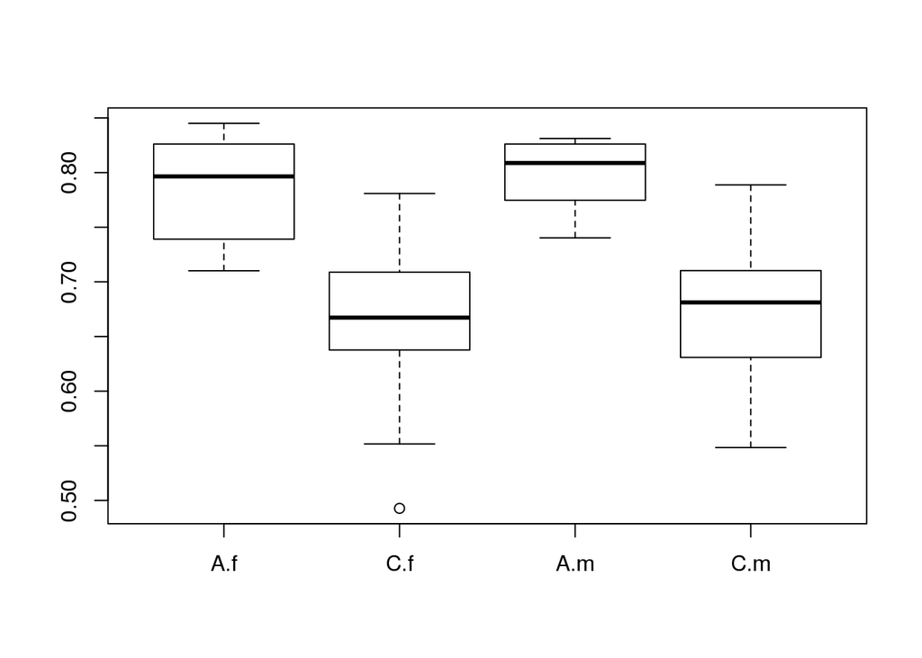

```r
boxplot(correct.mean ~ age_grp + sex, corrects)
```

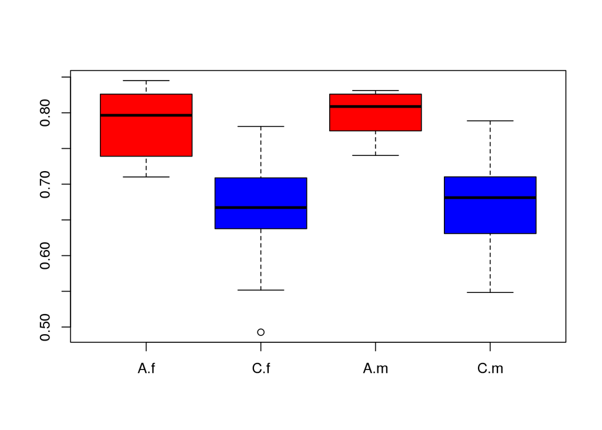

```r
# add some colors
boxplot(correct.mean ~ age_grp + sex, corrects, col=c("red", "blue"))
```

# Analysis of variance

Based on the boxplots, the interaction of age group and sex seems unlikely, but we could also test it. This cannot be tested with a t-test. We need analysis of variance.

The analysis of variance is a special case of linear model. Therefore, we can use the function lm to first fit a linear model.

```r
fm <- lm(correct.mean ~ age_grp * sex, corrects)
```

Here we need a formula again. age_grp * sex means that we want to include both the main effects and the interacion of the age_grp and sex to the model.

Function summary and are useful for inspecting the model. The fitted model can be also given to plot command, which shows some diagnostic information.

```r
summary(fm)
```

```
##
## Call:
## lm(formula = correct.mean ~ age_grp * sex, data = corrects)
##
## Residuals:
##      Min       1Q   Median       3Q      Max
## -0.17148 -0.03757  0.00853  0.03373  0.11680
##
## Coefficients:
##                Estimate Std. Error t value Pr(>|t|)
## (Intercept)    0.786161   0.012337  63.722  < 2e-16 ***
## age_grpC      -0.121925   0.017448  -6.988 8.76e-10 ***
## sexm           0.011279   0.022070   0.511    0.611
## age_grpC:sexm -0.003585   0.027628  -0.130    0.897
## ---
## Signif. codes:  0 '***' 0.001 '**' 0.01 '*' 0.05 '.' 0.1 ' ' 1
##
## Residual standard error: 0.05787 on 77 degrees of freedom
## Multiple R-squared:  0.5259, Adjusted R-squared:  0.5074
## F-statistic: 28.47 on 3 and 77 DF,  p-value: 1.723e-12
```

```r
anova(fm)
```

```
## Analysis of Variance Table
##
## Response: correct.mean
##             Df   Sum Sq  Mean Sq F value    Pr(>F)
## age_grp      1 0.284404 0.284404 84.9311 4.605e-14 ***
## sex          1 0.001536 0.001536  0.4587    0.5003
## age_grp:sex  1 0.000056 0.000056  0.0168    0.8971
## Residuals   77 0.257845 0.003349
## ---
## Signif. codes:  0 '***' 0.001 '**' 0.01 '*' 0.05 '.' 0.1 ' ' 1
```

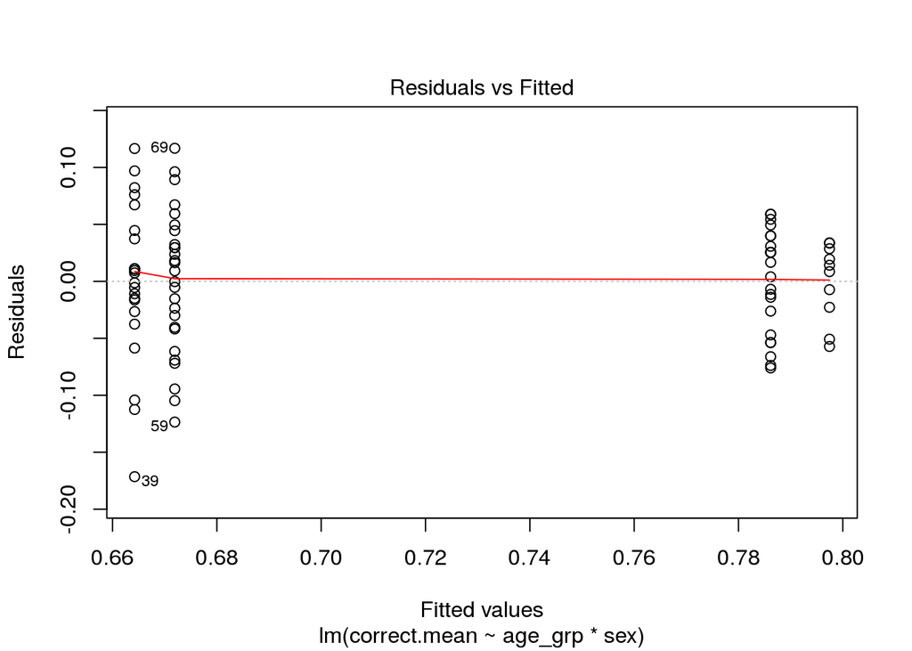

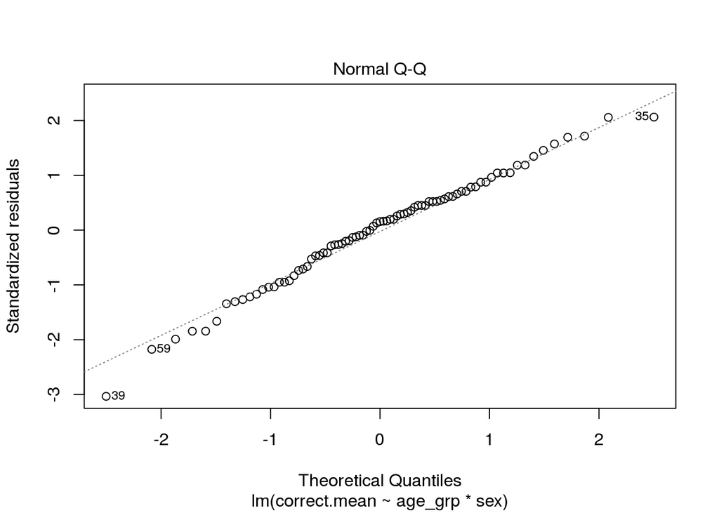

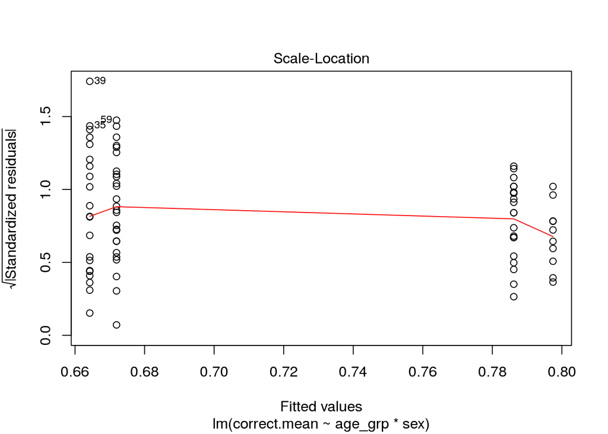

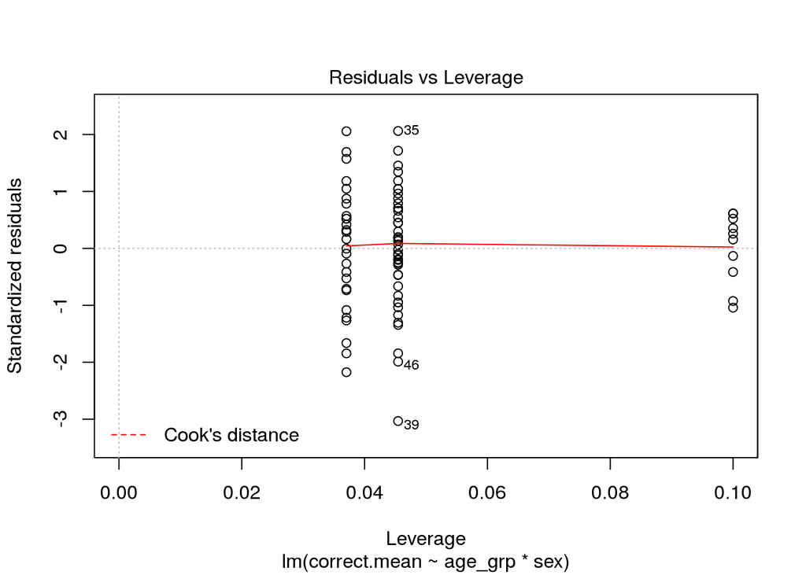

```r
plot(fm)
```

Unfortunately, there are multiple ways to calculate the Sums of Squares, which affect the F-values. The way above, uses type I of Sum of Squares. There are three points to consider. 1) It may not be the thing you want, 2) it may give misleading results when the data is not balanced (as is the case now), 3) SPSS/SAS uses the type III, so the results may be different.

The easiest way to overcome this problem is to use a package ez. A package, again!

There we have quite user friendly function ezANOVA.

```r
require(ez)
fm.ez <- ezANOVA(corrects,
        dv=correct.mean,
        wid=player_id,
        between = .(age_grp, sex))
```

```
## Warning: Data is unbalanced (unequal N per group). Make sure you specified
## a well-considered value for the type argument to ezANOVA().
```

We got a friendly warning that our data is unbalanced, and therefore we should pay attention to the choice of argument type, which controls which kind of Sum of Squares are used.

```r
fm.ez.ss1 <- ezANOVA(corrects,
        dv=correct.mean,
        wid=player_id,
        between = .(age_grp, sex),
        type=1)
```

```
## Warning: Data is unbalanced (unequal N per group). Make sure you specified
## a well-considered value for the type argument to ezANOVA().
```

```
## Warning: Using "type==1" is highly questionable when data are unbalanced
## and there is more than one variable. Hopefully you are doing this for
## demonstration purposes only!
```

```r
fm.ez.ss2 <- ezANOVA(corrects,
        dv=correct.mean,
        wid=player_id,
        between = .(age_grp, sex),
        type=2)
fm.ez.ss3 <- ezANOVA(corrects,
        dv=correct.mean,
        wid=player_id,
        between = .(age_grp, sex),
        type=3)
```

As we can see, the results are slightly different depending on the choice of SS type.

```r
fm.ez.ss1
```

```
## $ANOVA
##        Effect DFn DFd           F            p p<.05          ges
## 1     age_grp   1  77 84.93111261 4.605116e-14     * 0.5244891562
## 2         sex   1  77  0.45869970 5.002621e-01       0.0059218616
## 3 age_grp:sex   1  77  0.01683314 8.971084e-01       0.0002185644
```

```r
fm.ez.ss2
```

```
## $ANOVA
##        Effect DFn DFd           F            p p<.05          ges
## 1     age_grp   1  77 83.14336671 7.095284e-14     * 0.5191808341
## 2         sex   1  77  0.45869970 5.002621e-01       0.0059218616
## 3 age_grp:sex   1  77  0.01683314 8.971084e-01       0.0002185644
##
## $`Levene's Test for Homogeneity of Variance`
##   DFn DFd         SSn        SSd        F         p p<.05
## 1   3  77 0.005969388 0.09944495 1.540694 0.2107328
```

```r
fm.ez.ss3
```

```
## $ANOVA
##        Effect DFn DFd           F            p p<.05          ges
## 2     age_grp   1  77 80.20815594 1.458429e-13     * 0.5102035289
## 3         sex   1  77  0.47164149 4.942961e-01       0.0060879243
## 4 age_grp:sex   1  77  0.01683314 8.971084e-01       0.0002185644
##
## $`Levene's Test for Homogeneity of Variance`
##   DFn DFd         SSn        SSd        F         p p<.05
## 1   3  77 0.005969388 0.09944495 1.540694 0.2107328
```

Read more about the problems with unequal variance here: http://onlinestatbook.com/2/analysis_of_variance/unequal.html